# L14Ex_Acetylene_Rick_Davila

Rick Davila

6/01/2020

#### Perform data housekeeping - upload, name columns, display to make sure it reads properly, etc.

```r
knitr::opts_chunk$set(echo = TRUE)

library('xlsx') # Needed to read data
library(readxl)
library(ridge) # Needed for ridge regression in Example 9.2
library(pls) # Needed for principal component regression in Example 9.3
library(MASS) # Needed for ginv() function
library(car) # Needed for vif() function
library(xtable)

rm(list = ls())

# load data
Ex91 <- read.xlsx(
  "data-ex-9-1.xlsx",
  sheetIndex = 1, sheetName=NULL, rowIndex=NULL,
  startRow=NULL, endRow=NULL, colIndex= c(1,2,3,4,5),
  as.data.frame=TRUE, header=TRUE, colClasses=NA,
  keepFormulas=FALSE, encoding="unknown")

# Give labels to data columns
names(Ex91) <- c("Obs",
                 "conversion",
                 "temp",
                 "heptane",
                 "time")
attach(Ex91)

# Output data to make sure it reads properly
out <- as.data.frame(c(Ex91))
colnames(out) <- c("Obs",
                 "conversion",
                 "temp",
                 "heptane",
                 "time")
tab <- (xtable(out, digits=c(0,0,1,0,1,4)))
print(tab, type="html")
```

|  | Obs | conversion | temp | heptane | time |
| --- | --- | --- | --- | --- | --- |
| 1 | 1 | 49.0 | 1300 | 7.5 | 0.0120 |
| 2 | 2 | 50.2 | 1300 | 9.0 | 0.0120 |
| 3 | 3 | 50.5 | 1300 | 11.0 | 0.0115 |
| 4 | 4 | 48.5 | 1300 | 13.5 | 0.0130 |
| 5 | 5 | 47.5 | 1300 | 17.0 | 0.0135 |
| 6 | 6 | 44.5 | 1300 | 23.0 | 0.0120 |
| 7 | 7 | 28.0 | 1200 | 5.3 | 0.0400 |
| 8 | 8 | 31.5 | 1200 | 7.5 | 0.0380 |
| 9 | 9 | 34.5 | 1200 | 11.0 | 0.0320 |
| 10 | 10 | 35.0 | 1200 | 13.5 | 0.0260 |
| 11 | 11 | 38.0 | 1200 | 17.0 | 0.0340 |
| 12 | 12 | 38.5 | 1200 | 23.0 | 0.0410 |
| 13 | 13 | 15.0 | 1100 | 5.3 | 0.0840 |
| 14 | 14 | 17.0 | 1100 | 7.5 | 0.0980 |
| 15 | 15 | 20.5 | 1100 | 11.0 | 0.0920 |
| 16 | 16 | 29.5 | 1100 | 17.0 | 0.0860 |

```r
# Output data structure and dimensions
str(Ex91)
```

‘data.frame’: 16 obs. of 5 variables: $ Obs : num 1 2 3 4 5 6 7 8 9 10 … $ conversion: num 49 50.2 50.5 48.5 47.5 44.5 28 31.5 34.5 35 … $ temp : num 1300 1300 1300 1300 1300 1300 1200 1200 1200 1200 … $ heptane : num 7.5 9 11 13.5 17 23 5.3 7.5 11 13.5 … $ time : num 0.012 0.012 0.0115 0.013 0.0135 0.012 0.04 0.038 0.032 0.026 …

```r
dim(Ex91)
```

[1] 16 5

## Example 9.1 (p. 290-292)

#### Create scatterplot of Contact Time versus Reactor Temperature

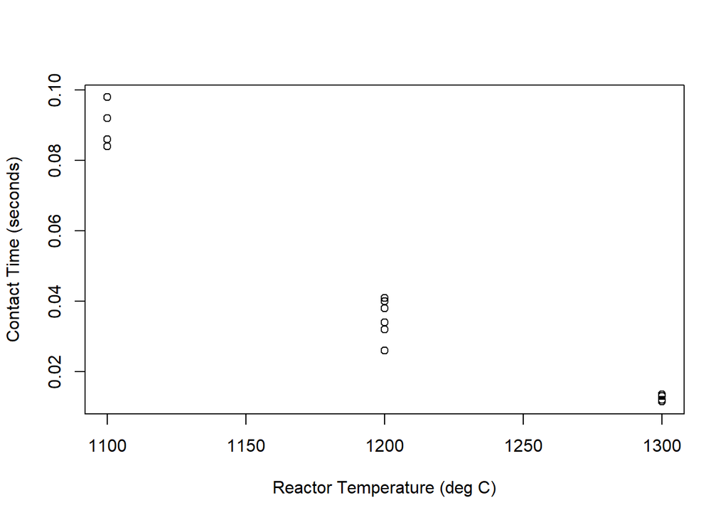

```r
plot(temp,time,
     xlab = "Reactor Temperature (deg C)",
     ylab = "Contact Time (seconds)")
```

#### Scale regressor variables using unit normal scaling

```r
P <- conversion
Ts <- (temp - mean(temp))/sd(temp)
Hs <- (heptane - mean(heptane))/sd(heptane)
Cs <- (time - mean(time))/sd(time)
```

#### Fit second order model using scaled regressors, to include two-way interaction terms. Compare to Table 9.2 on p. 293

##### Note: Can do this model the “long way”, i.e. lm(y ~ x1 + x2 + x3 + x1x2 + x2x3… etc.) or using polym() function in R.

##### Model output for the polym() shortcut uses a particular notation. Don’t get confused - know what you’re looking at.

##### Model both ways and use each model to decipher the polym() output.

```r
# model the "long way"
TsHs <- Ts*Hs
TsCs <- Ts*Cs
HsCs <- Hs*Cs
Ts_sqrd <- Ts*Ts
Hs_sqrd <- Hs*Hs
Cs_sqrd <- Cs*Cs

model.91 <- lm(P ~ Ts + Hs + Cs +
                 TsHs + TsCs + HsCs +
                 Ts_sqrd + Hs_sqrd + Cs_sqrd)

summary(model.91)
```

```
##
## Call:
## lm(formula = P ~ Ts + Hs + Cs + TsHs + TsCs + HsCs + Ts_sqrd +
##     Hs_sqrd + Cs_sqrd)
##
## Residuals:
##     Min      1Q  Median      3Q     Max
## -1.3499 -0.3411  0.1297  0.5011  0.6720
##
## Coefficients:
##             Estimate Std. Error t value Pr(>|t|)
## (Intercept)  35.8958     1.0916  32.884 5.26e-08 ***
## Ts            4.0038     4.5087   0.888 0.408719
## Hs            2.7783     0.3071   9.048 0.000102 ***
## Cs           -8.0423     6.0707  -1.325 0.233461
## TsHs         -6.4568     1.4660  -4.404 0.004547 **
## TsCs        -26.9804    21.0213  -1.283 0.246663
## HsCs         -3.7681     1.6553  -2.276 0.063116 .
## Ts_sqrd     -12.5236    12.3238  -1.016 0.348741
## Hs_sqrd      -0.9727     0.3746  -2.597 0.040844 *
## Cs_sqrd     -11.5932     7.7063  -1.504 0.183182
## ---
## Signif. codes:  0 '***' 0.001 '**' 0.01 '*' 0.05 '.' 0.1 ' ' 1
##
## Residual standard error: 0.9014 on 6 degrees of freedom
## Multiple R-squared:  0.9977, Adjusted R-squared:  0.9943
## F-statistic: 289.7 on 9 and 6 DF,  p-value: 3.225e-07
```

```r
anova(model.91)
```

|  | Df | Sum Sq | Mean Sq | F value | Pr(>F) |
| --- | --- | --- | --- | --- | --- |
| Ts | 1 | 1896.6769391 | 1896.6769391 | 2334.0918815 | 5.272579e-09 |
| Hs | 1 | 56.3015883 | 56.3015883 | 69.2859588 | 1.631506e-04 |
| Cs | 1 | 0.4407947 | 0.4407947 | 0.5424516 | 4.892028e-01 |
| TsHs | 1 | 143.4211476 | 143.4211476 | 176.4971827 | 1.124511e-05 |
| TsCs | 1 | 14.1014346 | 14.1014346 | 17.3535321 | 5.906382e-03 |
| HsCs | 1 | 1.2241399 | 1.2241399 | 1.5064532 | 2.656486e-01 |
| Ts_sqrd | 1 | 0.9480496 | 0.9480496 | 1.1666904 | 3.215755e-01 |
| Hs_sqrd | 1 | 3.8806445 | 3.8806445 | 4.7756055 | 7.153516e-02 |
| Cs_sqrd | 1 | 1.8390524 | 1.8390524 | 2.2631779 | 1.831824e-01 |
| Residuals | 6 | 4.8755843 | 0.8125974 | NA | NA |

```r
# model using polym()

model.91b <- lm(P ~ polym(Ts, Hs, Cs, degree = 2, raw=TRUE))
summary(model.91b)
```

```
##
## Call:
## lm(formula = P ~ polym(Ts, Hs, Cs, degree = 2, raw = TRUE))
##
## Residuals:
##     Min      1Q  Median      3Q     Max
## -1.3499 -0.3411  0.1297  0.5011  0.6720
##
## Coefficients:
##                                                Estimate Std. Error t value
## (Intercept)                                     35.8958     1.0916  32.884
## polym(Ts, Hs, Cs, degree = 2, raw = TRUE)1.0.0   4.0038     4.5087   0.888
## polym(Ts, Hs, Cs, degree = 2, raw = TRUE)2.0.0 -12.5236    12.3238  -1.016
## polym(Ts, Hs, Cs, degree = 2, raw = TRUE)0.1.0   2.7783     0.3071   9.048
## polym(Ts, Hs, Cs, degree = 2, raw = TRUE)1.1.0  -6.4568     1.4660  -4.404
## polym(Ts, Hs, Cs, degree = 2, raw = TRUE)0.2.0  -0.9727     0.3746  -2.597
## polym(Ts, Hs, Cs, degree = 2, raw = TRUE)0.0.1  -8.0423     6.0707  -1.325
## polym(Ts, Hs, Cs, degree = 2, raw = TRUE)1.0.1 -26.9804    21.0213  -1.283
## polym(Ts, Hs, Cs, degree = 2, raw = TRUE)0.1.1  -3.7681     1.6553  -2.276
## polym(Ts, Hs, Cs, degree = 2, raw = TRUE)0.0.2 -11.5932     7.7063  -1.504
##                                                Pr(>|t|)
## (Intercept)                                    5.26e-08 ***
## polym(Ts, Hs, Cs, degree = 2, raw = TRUE)1.0.0 0.408719
## polym(Ts, Hs, Cs, degree = 2, raw = TRUE)2.0.0 0.348741
## polym(Ts, Hs, Cs, degree = 2, raw = TRUE)0.1.0 0.000102 ***
## polym(Ts, Hs, Cs, degree = 2, raw = TRUE)1.1.0 0.004547 **
## polym(Ts, Hs, Cs, degree = 2, raw = TRUE)0.2.0 0.040844 *
## polym(Ts, Hs, Cs, degree = 2, raw = TRUE)0.0.1 0.233461
## polym(Ts, Hs, Cs, degree = 2, raw = TRUE)1.0.1 0.246663
## polym(Ts, Hs, Cs, degree = 2, raw = TRUE)0.1.1 0.063116 .
## polym(Ts, Hs, Cs, degree = 2, raw = TRUE)0.0.2 0.183182
## ---
## Signif. codes:  0 '***' 0.001 '**' 0.01 '*' 0.05 '.' 0.1 ' ' 1
##
## Residual standard error: 0.9014 on 6 degrees of freedom
## Multiple R-squared:  0.9977, Adjusted R-squared:  0.9943
## F-statistic: 289.7 on 9 and 6 DF,  p-value: 3.225e-07
```

```r
anova(model.91b)
```

|  | Df | Sum Sq | Mean Sq | F value | Pr(>F) |
| --- | --- | --- | --- | --- | --- |
| polym(Ts, Hs, Cs, degree = 2, raw = TRUE) | 9 | 2118.833791 | 235.4259767 | 289.7203 | 3.224875e-07 |
| Residuals | 6 | 4.875584 | 0.8125974 | NA | NA |

#### Reproduce Table 9.3 on p. 295.

```r
y <- (conversion - mean(conversion))/sqrt(sum((conversion - mean(conversion))^2))
x_1 <- (temp - mean(temp))/sqrt(sum((temp - mean(temp))^2))
x_2 <- (heptane - mean(heptane))/sqrt(sum((heptane - mean(heptane))^2))
x_3 <- (time - mean(time))/sqrt(sum((time - mean(time))^2))

x_12 <- x_1*x_2
x_12n <- (x_12 - mean(x_12))/sqrt(sum((x_12 - mean(x_12))^2))
x_13 <- x_1*x_3
x_13n <- (x_13 - mean(x_13))/sqrt(sum((x_13 - mean(x_13))^2))
x_23 <- x_2*x_3
x_23n <- (x_23 - mean(x_23))/sqrt(sum((x_23 - mean(x_23))^2))

x_11 <- x_1*x_1
x_11n <- (x_11 - mean(x_11))/sqrt(sum((x_11 - mean(x_11))^2))
x_22 <- x_2*x_2
x_22n <- (x_22 - mean(x_22))/sqrt(sum((x_22 - mean(x_22))^2))
x_33 <- x_3*x_3
x_33n <- (x_33 - mean(x_33))/sqrt(sum((x_33 - mean(x_33))^2))

# reproduce table 9.3
table_9pt3 <- data.frame(cbind(Obs,y,x_1,x_2,x_3,
                               x_12n,x_13n,x_23n,
                               x_11n,x_22n,x_33n))
out <- table_9pt3
colnames(out) <- c("Obs $i$","$y$","$x_1$","$x_2$","$x_3$",
                   "$x_1x_2$","$x_1x_3$","$x_2x_3$",
                   "$x_1^2$","$x_2^2$","$x_3^2$")
tab <- (xtable(out, digits=c(0,0,5,5,5,5,5,5,5,5,5,5)))
print(tab, type="html")
```

|  | Obs $i$ | $y$ | $x_1$ | $x_2$ | $x_3$ | $x_1x_2$ | $x_1x_3$ | $x_2x_3$ | $x_1^2$ | $x_2^2$ | $x_3^2$ |
| --- | --- | --- | --- | --- | --- | --- | --- | --- | --- | --- | --- |
| 1 | 1 | 0.27979 | 0.28022 | -0.22544 | -0.23106 | -0.33783 | -0.02098 | 0.30974 | 0.07828 | -0.04091 | -0.03436 |
| 2 | 2 | 0.30583 | 0.28022 | -0.15704 | -0.23106 | -0.25390 | -0.02098 | 0.23679 | 0.07828 | -0.13259 | -0.03436 |
| 3 | 3 | 0.31234 | 0.28022 | -0.06584 | -0.23514 | -0.14199 | -0.02592 | 0.14076 | 0.07828 | -0.20382 | -0.02719 |
| 4 | 4 | 0.26894 | 0.28022 | 0.04817 | -0.22289 | -0.00210 | -0.01111 | 0.01975 | 0.07828 | -0.21088 | -0.04833 |
| 5 | 5 | 0.24724 | 0.28022 | 0.20777 | -0.21881 | 0.19375 | -0.00617 | -0.14055 | 0.07828 | -0.06774 | -0.05512 |
| 6 | 6 | 0.18214 | 0.28022 | 0.48138 | -0.23106 | 0.52948 | -0.02098 | -0.44410 | 0.07828 | 0.59301 | -0.03436 |
| 7 | 7 | -0.17590 | -0.04003 | -0.32577 | -0.00255 | -0.00410 | 0.25902 | 0.07314 | -0.29746 | 0.15287 | -0.23562 |
| 8 | 8 | -0.09995 | -0.04003 | -0.22544 | -0.01887 | -0.02168 | 0.26184 | 0.08894 | -0.29746 | -0.04091 | -0.23430 |
| 9 | 9 | -0.03486 | -0.04003 | -0.06584 | -0.06784 | -0.04966 | 0.27030 | 0.08992 | -0.29746 | -0.20382 | -0.21829 |
| 10 | 10 | -0.02401 | -0.04003 | 0.04817 | -0.11680 | -0.06964 | 0.27876 | 0.04334 | -0.29746 | -0.21088 | -0.18421 |
| 11 | 11 | 0.04109 | -0.04003 | 0.20777 | -0.05152 | -0.09762 | 0.26748 | 0.01990 | -0.29746 | -0.06774 | -0.22564 |
| 12 | 12 | 0.05194 | -0.04003 | 0.48138 | 0.00561 | -0.14558 | 0.25761 | 0.08177 | -0.29746 | 0.59301 | -0.23552 |
| 13 | 13 | -0.45800 | -0.36029 | -0.32577 | 0.35653 | 0.45274 | -0.29604 | -0.46680 | 0.32877 | 0.15287 | 0.24361 |
| 14 | 14 | -0.41460 | -0.36029 | -0.22544 | 0.47078 | 0.29447 | -0.47378 | -0.42060 | 0.32877 | -0.04091 | 0.59999 |
| 15 | 15 | -0.33865 | -0.36029 | -0.06584 | 0.42182 | 0.04267 | -0.39761 | -0.05888 | 0.32877 | -0.20382 | 0.43520 |
| 16 | 16 | -0.14335 | -0.36029 | 0.20777 | 0.37285 | -0.38899 | -0.32143 | 0.42688 | 0.32877 | -0.06774 | 0.28850 |

#### Using Table 9.3 data, define an X matrix and perform eigensystem analysis of X’X. Compare to Table 9.10 on p. 316

```r
#X <- cbind(matrix(1,length(Distance),1),as.matrix(Num_Cases),as.m#atrix(Distance))

X <- cbind(as.matrix(x_1),as.matrix(x_2),as.matrix(x_3),
           as.matrix(x_12n),as.matrix(x_13n),as.matrix(x_23n),
           as.matrix(x_11n),as.matrix(x_22n),as.matrix(x_33n))

xtx <- t(X) %*% X

ev <- eigen(xtx)$vectors
lambda <- eigen(xtx)$values

# eigenvectors
as.matrix(ev)
```

```
##              [,1]        [,2]         [,3]        [,4]        [,5]        [,6]
##  [1,] -0.33869118 -0.10576185  0.649400352  0.01210303 -0.14255274  0.24948972
##  [2,] -0.13235854 -0.33901571 -0.001449742 -0.72472286  0.58389085 -0.02070227
##  [3,]  0.41362212  0.09799876 -0.469273272 -0.07524924  0.01846900 -0.01603244
##  [4,]  0.21951175 -0.54005584  0.087054424  0.36162698  0.16633108 -0.36623974
##  [5,] -0.44916992 -0.08641133 -0.287944901  0.18937808  0.09446653 -0.02922040
##  [6,] -0.25275845  0.51719668 -0.054712522 -0.34488485 -0.20103944 -0.31549409
##  [7,]  0.40557509  0.07476183  0.441686924 -0.21950491 -0.14430892 -0.54068922
##  [8,] -0.02555615 -0.53163292 -0.221360350 -0.34290917 -0.73441660  0.07075512
##  [9,]  0.46660059  0.09714164  0.143135377 -0.13272171  0.03477733  0.63655026
##               [,7]        [,8]         [,9]
##  [1,] -0.221473239 -0.53874409  0.174279714
##  [2,] -0.011303829 -0.02878024 -0.003323561
##  [3,] -0.168848097 -0.71289256  0.236874442
##  [4,] -0.589696292  0.11070661  0.002547737
##  [5,]  0.062038024  0.15041172  0.797341195
##  [6,] -0.620187593  0.14841251  0.008333273
##  [7,]  0.318930658  0.04769084  0.411690042
##  [8,] -0.002471479  0.07563638  0.005021362
##  [9,] -0.290458587  0.36852341  0.328881761
```

```r
# eigenvalues
as.matrix(lambda)
```

```
##               [,1]
##  [1,] 4.205230e+00
##  [2,] 2.161999e+00
##  [3,] 1.138677e+00
##  [4,] 1.040475e+00
##  [5,] 3.852305e-01
##  [6,] 4.953807e-02
##  [7,] 1.362526e-02
##  [8,] 5.127803e-03
##  [9,] 9.693644e-05
```

#### Calculate kappa values and compare to p. 298

```r
kappa <- max(lambda)/lambda
as.matrix(kappa)
```

```
##               [,1]
##  [1,]     1.000000
##  [2,]     1.945066
##  [3,]     3.693085
##  [4,]     4.041644
##  [5,]    10.916141
##  [6,]    84.888858
##  [7,]   308.634770
##  [8,]   820.084287
##  [9,] 43381.314197
```

## Example 9.2 (p.307-308)

##### Perform ridge regression (by hand) using the standardized data from Table 9.3. Define the parameter k as a constant and vary to reproduce Table 9.8 on p. 308

##### Note: The textbook leaves off the intercept term. This is because the response and the regressors are both centered and scaled. Due to rounding, the output will give a small B_0 coefficient.

##### We could have also dropped the vector of ones from X

```r
# create identity matrix (9x9)
I_matrix <- diag(9)

# k matrix
k_matrix <- c(0.000,0.001,0.004,0.008,0.016,0.032,0.064,0.128,0.512)

# create blank matrix for storage (9x9)
mstore <- matrix(nrow = 9, ncol = length(k_matrix))

for (kval in seq(1:length(k_matrix))) {
  matrix_in <- xtx + k_matrix[kval]*I_matrix
  beta_R <- ginv(matrix_in, tol = .Machine$double.eps) %*% t(X) %*%  y

  mstore[,kval] <- as.matrix(beta_R[,1])
}

out <- as.data.frame(mstore)
colnames(out) <- c("$0.000$","$0.001$","$0.004$",
                   "$0.008$","$0.016$","$0.032$",
                   "$0.064$","$0.128$","$0.512$")

rownames(out) <- c("$beta_{R1}$","$beta_{R2}$","$beta_{R3}$",
                   "$beta_{R12}$","$beta_{R13}$","$beta_{R23}$",
                   "$beta_{R11}$","$beta_{R22}$","$beta_{R33}$")

tab <- (xtable(out, digits=c(0,4,4,4,4,4,4,4,4,4)))
print(tab, type="html")
```

|  | $0.000$ | $0.001$ | $0.004$ | $0.008$ | $0.016$ | $0.032$ | $0.064$ | $0.128$ | $0.512$ |
| --- | --- | --- | --- | --- | --- | --- | --- | --- | --- |
| $beta_{R1}$ | 0.3365 | 0.6765 | 0.6359 | 0.6001 | 0.5670 | 0.5390 | 0.5121 | 0.4805 | 0.3784 |
| $beta_{R2}$ | 0.2335 | 0.2240 | 0.2197 | 0.2172 | 0.2147 | 0.2117 | 0.2066 | 0.1971 | 0.1554 |
| $beta_{R3}$ | -0.6759 | -0.2133 | -0.2672 | -0.3135 | -0.3515 | -0.3735 | -0.3799 | -0.3723 | -0.3108 |
| $beta_{R12}$ | -0.4800 | -0.4479 | -0.3913 | -0.3437 | -0.2880 | -0.2329 | -0.1863 | -0.1509 | -0.1045 |
| $beta_{R13}$ | -2.0340 | -0.2776 | -0.1352 | -0.1018 | -0.0810 | -0.0676 | -0.0570 | -0.0455 | -0.0093 |
| $beta_{R23}$ | -0.2657 | -0.2173 | -0.1536 | -0.1020 | -0.0433 | 0.0123 | 0.0562 | 0.0848 | 0.0991 |
| $beta_{R11}$ | -0.8345 | 0.0642 | 0.1213 | 0.1262 | 0.1253 | 0.1248 | 0.1257 | 0.1229 | 0.0827 |
| $beta_{R22}$ | -0.0904 | -0.0731 | -0.0621 | -0.0558 | -0.0509 | -0.0480 | -0.0464 | -0.0444 | -0.0342 |
| $beta_{R33}$ | -1.0009 | -0.2450 | -0.1313 | -0.0825 | -0.0455 | -0.0266 | -0.0250 | -0.0338 | -0.0585 |

#### There is also a package to perform ridge regression automatically

```r
# example using automated calculation ... for k = 0.032
linRidgeMod <- linearRidge(y ~ x_1 + x_2 + x_3 + x_12n + x_13n + x_23n + x_11n + x_22n + x_33n,
                           lambda = 0.032)
print(summary(linRidgeMod), type="html")
```

```
##
## Call:
## linearRidge(formula = y ~ x_1 + x_2 + x_3 + x_12n + x_13n + x_23n +
##     x_11n + x_22n + x_33n, lambda = 0.032)
##
##
## Coefficients:
##               Estimate Scaled estimate Std. Error (scaled) t value (scaled)
## (Intercept) -6.122e-17              NA                  NA               NA
## x_1          5.390e-01       5.390e-01           3.704e-02           14.553
## x_2          2.117e-01       2.117e-01           2.780e-02            7.614
## x_3         -3.735e-01      -3.735e-01           3.722e-02           10.035
## x_12n       -2.329e-01      -2.329e-01           4.671e-02            4.987
## x_13n       -6.758e-02      -6.758e-02           1.441e-02            4.691
## x_23n        1.228e-02       1.228e-02           4.688e-02            0.262
## x_11n        1.248e-01       1.248e-01           4.347e-02            2.870
## x_22n       -4.804e-02      -4.804e-02           3.021e-02            1.590
## x_33n       -2.663e-02      -2.663e-02           4.998e-02            0.533
##             Pr(>|t|)
## (Intercept)       NA
## x_1          < 2e-16 ***
## x_2         2.66e-14 ***
## x_3          < 2e-16 ***
## x_12n       6.15e-07 ***
## x_13n       2.72e-06 ***
## x_23n         0.7934
## x_11n         0.0041 **
## x_22n         0.1117
## x_33n         0.5941
## ---
## Signif. codes:  0 '***' 0.001 '**' 0.01 '*' 0.05 '.' 0.1 ' ' 1
##
## Ridge parameter: 0.032
##
## Degrees of freedom: model 5.891 , variance 5.173 , residual 6.609
```

```r
# create blank matrix for storage (9x9)
mstore2 <- matrix(nrow = 9, ncol = length(k_matrix))

# loop through the values
for (kval in seq(1:length(k_matrix))) {
  linRidgeMod <- linearRidge(y ~ x_1 + x_2 + x_3 + x_12n + x_13n + x_23n + x_11n + x_22n + x_33n,
                           lambda = k_matrix[kval])

  beta_R <- linRidgeMod$coef
  mstore2[,kval] <- as.matrix(beta_R[,1])
}

out <- as.data.frame(mstore2)
colnames(out) <- c("$0.000$","$0.001$","$0.004$",
                   "$0.008$","$0.016$","$0.032$",
                   "$0.064$","$0.128$","$0.512$")

rownames(out) <- c("$beta_{R1}$","$beta_{R2}$","$beta_{R3}$",
                   "$beta_{R12}$","$beta_{R13}$","$beta_{R23}$",
                   "$beta_{R11}$","$beta_{R22}$","$beta_{R33}$")

tab <- (xtable(out, digits=c(0,4,4,4,4,4,4,4,4,4)))
print(tab, type="html")
```

|  | $0.000$ | $0.001$ | $0.004$ | $0.008$ | $0.016$ | $0.032$ | $0.064$ | $0.128$ | $0.512$ |
| --- | --- | --- | --- | --- | --- | --- | --- | --- | --- |
| $beta_{R1}$ | 0.3365 | 0.6765 | 0.6359 | 0.6001 | 0.5670 | 0.5390 | 0.5121 | 0.4805 | 0.3784 |
| $beta_{R2}$ | 0.2335 | 0.2240 | 0.2197 | 0.2172 | 0.2147 | 0.2117 | 0.2066 | 0.1971 | 0.1554 |
| $beta_{R3}$ | -0.6759 | -0.2133 | -0.2672 | -0.3135 | -0.3515 | -0.3735 | -0.3799 | -0.3723 | -0.3108 |
| $beta_{R12}$ | -0.4800 | -0.4479 | -0.3913 | -0.3437 | -0.2880 | -0.2329 | -0.1863 | -0.1509 | -0.1045 |
| $beta_{R13}$ | -2.0340 | -0.2776 | -0.1352 | -0.1018 | -0.0810 | -0.0676 | -0.0570 | -0.0455 | -0.0093 |
| $beta_{R23}$ | -0.2657 | -0.2173 | -0.1536 | -0.1020 | -0.0433 | 0.0123 | 0.0562 | 0.0848 | 0.0991 |
| $beta_{R11}$ | -0.8345 | 0.0642 | 0.1213 | 0.1262 | 0.1253 | 0.1248 | 0.1257 | 0.1229 | 0.0827 |
| $beta_{R22}$ | -0.0904 | -0.0731 | -0.0621 | -0.0558 | -0.0509 | -0.0480 | -0.0464 | -0.0444 | -0.0342 |
| $beta_{R33}$ | -1.0009 | -0.2450 | -0.1313 | -0.0825 | -0.0455 | -0.0266 | -0.0250 | -0.0338 | -0.0585 |

## Example 9.3 (p.316-319)

#### Perform Principal Component Regression using the pcr() function. Display $coefficients, $loadings, and $scores. Compare to Table 9.12 on p. 318 and Table 9.10 on p. 3.16

```r
pcr.model <- pcr(y ~ x_1 + x_2 + x_3 + x_12n + x_13n + x_23n + x_11n + x_22n + x_33n)


pcr.model$coefficients
```

```
## , , 1 comps
##
##                  y
## x_1    0.119286603
## x_2    0.046616509
## x_3   -0.145677187
## x_12n -0.077311759
## x_13n  0.158197077
## x_23n  0.089021205
## x_11n -0.142843030
## x_22n  0.009000843
## x_33n -0.164336136
##
## , , 2 comps
##
##                  y
## x_1    0.118761294
## x_2    0.044932650
## x_3   -0.145190437
## x_12n -0.079994165
## x_13n  0.157767881
## x_23n  0.091590072
## x_11n -0.142471695
## x_22n  0.006360273
## x_33n -0.163853643
##
## , , 3 comps
##
##                 y
## x_1    0.50964555
## x_2    0.04406003
## x_3   -0.42765338
## x_12n -0.02759474
## x_13n -0.01555067
## x_23n  0.05865775
## x_11n  0.12338659
## x_22n -0.12687999
## x_33n -0.07769821
##
## , , 4 comps
```

[output cut: 61 more lines]

```
## x_22n -0.07829981
## x_33n -0.21133755
##
## , , 9 comps
##
##                 y
## x_1    0.33648681
## x_2    0.23349593
## x_3   -0.67589625
## x_12n -0.47995686
## x_13n -2.03395608
## x_23n -0.26571830
## x_11n -0.83454188
## x_22n -0.09035419
## x_33n -1.00085767
```

```r
pcr.model$loadings
```

```
##
## Loadings:
##       Comp 1 Comp 2 Comp 3 Comp 4 Comp 5 Comp 6 Comp 7 Comp 8 Comp 9
## x_1   -0.339  0.106 -0.649        -0.143  0.249  0.221  0.539  0.174
## x_2   -0.132  0.339        -0.725  0.584
## x_3    0.414         0.469                       0.169  0.713  0.237
## x_12n  0.220  0.540         0.362  0.166 -0.366  0.590 -0.111
## x_13n -0.449         0.288  0.189                      -0.150  0.797
## x_23n -0.253 -0.517        -0.345 -0.201 -0.315  0.620 -0.148
## x_11n  0.406        -0.442 -0.220 -0.144 -0.541 -0.319         0.412
## x_22n         0.532  0.221 -0.343 -0.734
## x_33n  0.467        -0.143 -0.133         0.637  0.290 -0.369  0.329
##
##                Comp 1 Comp 2 Comp 3 Comp 4 Comp 5 Comp 6 Comp 7 Comp 8 Comp 9
## SS loadings     1.000  1.000  1.000  1.000  1.000  1.000  1.000  1.000  1.000
## Proportion Var  0.111  0.111  0.111  0.111  0.111  0.111  0.111  0.111  0.111
## Cumulative Var  0.111  0.222  0.333  0.444  0.556  0.667  0.778  0.889  1.000
```

```r
pcr.model$scores
```

```
##         Comp 1       Comp 2      Comp 3        Comp 4        Comp 5
## 1  -0.28690261 -0.392872499 -0.28913032 -4.739909e-02 -0.2787385504
## 2  -0.25674961 -0.335363264 -0.32062355 -1.002155e-02 -0.1428408383
## 3  -0.21428631 -0.232931019 -0.35561835  2.031625e-02  0.0003526641
## 4  -0.17935422 -0.057765472 -0.36277947  3.712793e-02  0.1205896097
## 5  -0.12433170  0.261802466 -0.35237199  8.711463e-06  0.1737614026
## 6  -0.01573294  1.042049111 -0.26452817 -2.033993e-01 -0.0357791054
## 7  -0.31459412 -0.005685441  0.30221559  3.022900e-01 -0.2530074625
## 8  -0.33817857 -0.090649401  0.25482581  2.858091e-01 -0.0582057530
## 9  -0.37811434 -0.134788686  0.19865201  2.187104e-01  0.1502325054
## 10 -0.39378521 -0.084373112  0.17102538  1.481121e-01  0.2291050319
## 11 -0.40604548  0.039499473  0.23741504 -2.022899e-02  0.2159274568
## 12 -0.46186296  0.420139869  0.41701560 -4.886373e-01 -0.1302162345
## 13  0.90606065  0.309895052  0.10436827  3.166369e-01 -0.1423239975
## 14  1.14468703  0.070336943  0.02935362  1.476504e-01  0.0206675579
```

[output cut: 21 more lines]

#### Perform Principal Component Regression (by hand) using the following steps:

#### Define matrix of eigenvectors of xTx, where X is defined by standardized variables (Table 9.3)

```r
xTx <- t(X) %*% X
```

#### Calculate Z; omit intercept row/column because variables are standardized. Compare to $scores output from pcr().

```r
# ev is the eigenvectgor matrix

Z <- X %*% as.matrix(ev)
Z
```

```
##              [,1]         [,2]        [,3]          [,4]          [,5]
##  [1,] -0.28690261  0.392872499  0.28913032 -4.739909e-02 -0.2787385504
##  [2,] -0.25674961  0.335363264  0.32062355 -1.002155e-02 -0.1428408383
##  [3,] -0.21428631  0.232931019  0.35561835  2.031625e-02  0.0003526641
##  [4,] -0.17935422  0.057765472  0.36277947  3.712793e-02  0.1205896097
##  [5,] -0.12433170 -0.261802466  0.35237199  8.711463e-06  0.1737614026
##  [6,] -0.01573294 -1.042049111  0.26452817 -2.033993e-01 -0.0357791054
##  [7,] -0.31459412  0.005685441 -0.30221559  3.022900e-01 -0.2530074625
##  [8,] -0.33817857  0.090649401 -0.25482581  2.858091e-01 -0.0582057530
##  [9,] -0.37811434  0.134788686 -0.19865201  2.187104e-01  0.1502325054
## [10,] -0.39378521  0.084373112 -0.17102538  1.481121e-01  0.2291050319
## [11,] -0.40604548 -0.039499473 -0.23741504 -2.022899e-02  0.2159274568
## [12,] -0.46186296 -0.420139869 -0.41701560 -4.886373e-01 -0.1302162345
## [13,]  0.90606065 -0.309895052 -0.10436827  3.166369e-01 -0.1423239975
## [14,]  1.14468703 -0.070336943 -0.02935362  1.476504e-01  0.0206675579
```

[output cut: 19 more lines]

#### Obtain least squares estimators for alpha

```r
alpha_hat <- ginv(t(Z) %*% Z, tol = .Machine$double.eps) %*% t(Z) %*%  y

as.matrix(alpha_hat)
```

```
##               [,1]
##  [1,] -0.352198731
##  [2,]  0.004966905
##  [3,]  0.601915680
##  [4,] -0.234391618
##  [5,]  0.009315548
##  [6,]  0.216735789
##  [7,]  0.383372953
##  [8,] -0.520133632
##  [9,] -2.400619956
```

#### Define vector of ones and zeros to determine cutoff of principal components to use

```r
b_p <- c(1,1,1,1,1,0,0,0,0)
```

#### Define alpha_pc as per p.315 (equation not numbered). Note that this is term-by-term multiplication, not the dot product

```r
alpha_pc <- alpha_hat * b_p
```

#### Calculate beta_pc using Equation 9.10. Compare results to Table 9.12 on p. 318.Vary B vector to obtain standardized estimates in columns A, B, C, D, and E

```r
beta_pc <- as.matrix(ev) %*% alpha_pc
as.matrix(beta_pc)
```

```
##              [,1]
##  [1,]  0.50548074
##  [2,]  0.21936825
##  [3,] -0.40984354
##  [4,] -0.11080761
##  [5,] -0.05905930
##  [6,]  0.13762307
##  [7,]  0.17349238
##  [8,] -0.05334645
##  [9,] -0.04626539
```

#### Calculate beta_pc using Equation 9.10. Compare results to Table 9.12 on p. 318.Vary B vector to obtain standardized estimates in columns A, B, C, D, and E

#### Column A

```r
b_p <- c(1,0,0,0,0,0,0,0,0)
alpha_pc <- alpha_hat * b_p
beta_pc <- as.matrix(ev) %*% alpha_pc
as.matrix(beta_pc)
```

```
##               [,1]
##  [1,]  0.119286603
##  [2,]  0.046616509
##  [3,] -0.145677187
##  [4,] -0.077311759
##  [5,]  0.158197077
##  [6,]  0.089021205
##  [7,] -0.142843030
##  [8,]  0.009000843
##  [9,] -0.164336136
```

#### Column B

```r
b_p <- c(1,1,0,0,0,0,0,0,0)
alpha_pc <- alpha_hat * b_p
beta_pc <- as.matrix(ev) %*% alpha_pc
as.matrix(beta_pc)
```

```
##               [,1]
##  [1,]  0.118761294
##  [2,]  0.044932650
##  [3,] -0.145190437
##  [4,] -0.079994165
##  [5,]  0.157767881
##  [6,]  0.091590072
##  [7,] -0.142471695
##  [8,]  0.006360273
##  [9,] -0.163853643
```

#### Column C

```r
b_p <- c(1,1,1,0,0,0,0,0,0)
alpha_pc <- alpha_hat * b_p
beta_pc <- as.matrix(ev) %*% alpha_pc
as.matrix(beta_pc)
```

```
##              [,1]
##  [1,]  0.50964555
##  [2,]  0.04406003
##  [3,] -0.42765338
##  [4,] -0.02759474
##  [5,] -0.01555067
##  [6,]  0.05865775
##  [7,]  0.12338659
##  [8,] -0.12687999
##  [9,] -0.07769821
```

#### Column D

```r
b_p <- c(1,1,1,1,0,0,0,0,0)
alpha_pc <- alpha_hat * b_p
beta_pc <- as.matrix(ev) %*% alpha_pc
as.matrix(beta_pc)
```

```
##              [,1]
##  [1,]  0.50680870
##  [2,]  0.21392899
##  [3,] -0.41001559
##  [4,] -0.11235708
##  [5,] -0.05993930
##  [6,]  0.13949587
##  [7,]  0.17483670
##  [8,] -0.04650496
##  [9,] -0.04658936
```

#### Column E

```r
b_p <- c(1,1,1,1,1,0,0,0,0)
alpha_pc <- alpha_hat * b_p
beta_pc <- as.matrix(ev) %*% alpha_pc
as.matrix(beta_pc)
```

```
##              [,1]
##  [1,]  0.50548074
##  [2,]  0.21936825
##  [3,] -0.40984354
##  [4,] -0.11080761
##  [5,] -0.05905930
##  [6,]  0.13762307
##  [7,]  0.17349238
##  [8,] -0.05334645
##  [9,] -0.04626539
```